# Lab: Interaction Terms

Chris Troeger

2/9/2022

# Demo or refresher on interaction terms in R

This lab will give a couple examples of specifying and interpreting interaction terms in R.

### Grab Ghana Bednet data

Let’s say we have a hypothesis that there is an interaction between age and effectiveness of bednet. First we will build a basic model and iterate on it. Let’s keep it simple and not consider clustering.

```r
dt$row <- 1
# make sex a factor for later
dt[, sex := factor(sex, levels = c(0,1), labels = c("Female","Male"))]
tab_dt <- dt[, lapply(.SD, function(x) sum(x)),
             .SDcols = c("row","outcome","follyr"),
             by = c("cluster","bednet","agegp","sex")]
```

My model is:

$$Y_i \sim \beta_0 + \beta_1bednet_i + \beta_2sex_i + \beta_3agegroup_i + \epsilon_i$$

Seems like it!

```r
mod0 <- glm(outcome ~ offset(log(follyr)) + bednet + agegp + sex, data = dt, family = poisson)
print_md(model_parameters(mod0, exponentiate = T))
```

| Parameter | IRR | SE | 95% CI | z | p |
| --- | --- | --- | --- | --- | --- |
| (Intercept) | 0.05 | 3.25e-03 | (0.05, 0.06) | -47.63 | < .001 |
| bednet | 0.83 | 0.06 | (0.73, 0.95) | -2.65 | 0.008 |
| agegp | 0.56 | 0.02 | (0.52, 0.60) | -16.52 | < .001 |
| sex (Male) | 0.94 | 0.06 | (0.82, 1.08) | -0.85 | 0.394 |

Let’s consider two ways to specify an interaction term between variables. [Useful link](https://conjugateprior.org/2013/01/formulae-in-r-anova/)

1. Specifying an interaction with the `colon (:)` icon will return a model with those variables *only* as interaction terms. `glm(y ~ a:b)`

$$Y_i \sim \beta_{a,b}$$

2. Specifying an interaction with the `asterisk (*)` icon will return a model with those variables separately and as an interaction term. `glm(y ~ a*b)`

$$Y_i \sim \beta{a} + \beta_b + \beta_{a,b}$$

```r
mod1 <- glm(outcome ~ offset(log(follyr)) + bednet:agegp + sex, data = dt, family = poisson)
print_md(model_parameters(mod1, exponentiate = T))
```

| Parameter | IRR | SE | 95% CI | z | p |
| --- | --- | --- | --- | --- | --- |
| (Intercept) | 0.03 | 1.60e-03 | (0.03, 0.04) | -69.29 | < .001 |
| sex (Male) | 0.95 | 0.07 | (0.83, 1.09) | -0.73 | 0.466 |
| bednet * agegp | 0.66 | 0.03 | (0.61, 0.72) | -9.53 | < .001 |

```r
mod2 <- glm(outcome ~ offset(log(follyr)) + bednet*agegp + sex, data = dt, family = poisson)
print_md(model_parameters(mod2, exponentiate = T))
```

| Parameter | IRR | SE | 95% CI | z | p |
| --- | --- | --- | --- | --- | --- |
| (Intercept) | 0.05 | 3.53e-03 | (0.05, 0.06) | -44.65 | < .001 |
| bednet | 0.79 | 0.07 | (0.67, 0.93) | -2.87 | 0.004 |
| agegp | 0.54 | 0.03 | (0.49, 0.59) | -12.67 | < .001 |
| sex (Male) | 0.94 | 0.06 | (0.82, 1.08) | -0.86 | 0.388 |
| bednet * agegp | 1.09 | 0.08 | (0.95, 1.25) | 1.23 | 0.221 |

```r
# mod2 is the same as writing
# glm(outcome ~ offset(log(follyr)) + bednet + agegp + bednet:agegp + sex, data = dt, family = poisson)
```

Interpreting coefficients from interaction terms can be tricky.

- `intercept` = incidence of malaria when `bednet = 0, agegp = 0, sex = "Female"`
- `bednet` = decrease in risk of malaria when `bednet = 1"`
- `agegp` = decrease in risk of malaria for each 1 unit increase in `agegp` when `bednet = 0`
- `sexMale` = decrease in risk of malaria when `sex = "Male"`
- `bednet:agegp` = increase in risk of malaria for each 1 unit increase in `agegp` when `bednet = 1`

Note that we can add interaction terms to a mixed-effects model in exactly the same way:

```r
mod3 <- glmer(outcome ~ offset(log(follyr)) + bednet*agegp + sex + (1 | cluster), data = dt, family = poisson)
print_md(model_parameters(mod3, exponentiate = T))
```

Fixed Effects

| Parameter | IRR | SE | 95% CI | z | p |
| --- | --- | --- | --- | --- | --- |
| (Intercept) | 0.05 | 3.92e-03 | (0.05, 0.06) | -39.32 | < .001 |
| bednet | 0.79 | 0.08 | (0.66, 0.96) | -2.39 | 0.017 |
| agegp | 0.54 | 0.03 | (0.49, 0.59) | -12.69 | < .001 |
| sex (Male) | 0.94 | 0.06 | (0.82, 1.08) | -0.86 | 0.389 |
| bednet * agegp | 1.09 | 0.08 | (0.95, 1.25) | 1.24 | 0.214 |

Random Effects

| Parameter | Coefficient |
| --- | --- |
| SD (Intercept: cluster) | 0.24 |
| SD (Residual) | 1.00 |

### Compare predictions

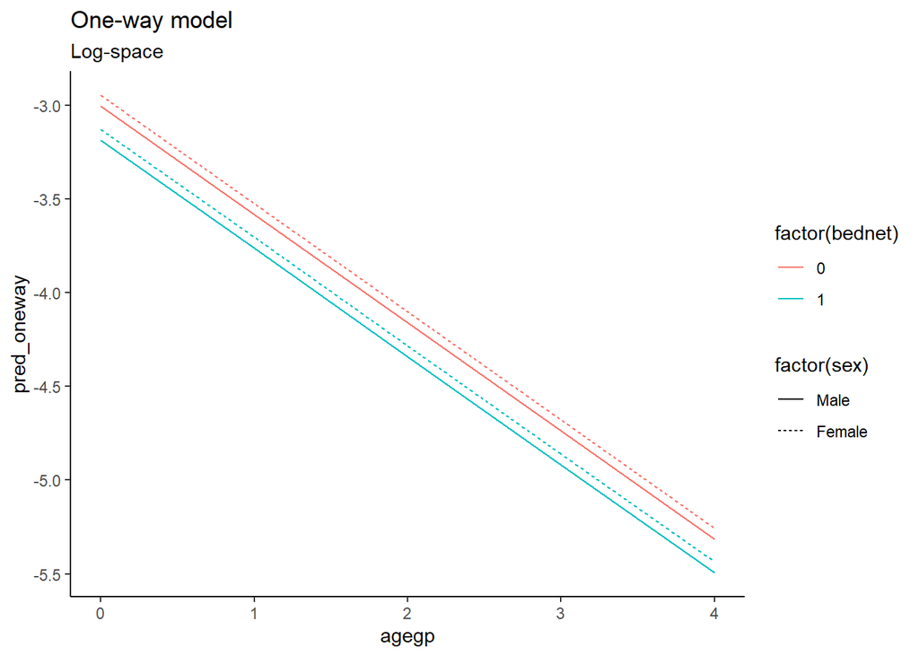

```r
pred_dt <- expand.grid(agegp = 0:4,
                       sex = c("Male","Female"),
                       bednet = c(0,1),
                       follyr = 1)

# predict model without interaction
pred_dt$pred_oneway <- predict(mod0, newdata = pred_dt)
# predict model with interaction
pred_dt$pred <- predict(mod2, newdata = pred_dt)

ggplot(pred_dt, aes(x = agegp, y = pred_oneway, lty = factor(sex), col = factor(bednet))) + geom_line() +
  theme_classic() + ggtitle("One-way model", subtitle = "Log-space")
```

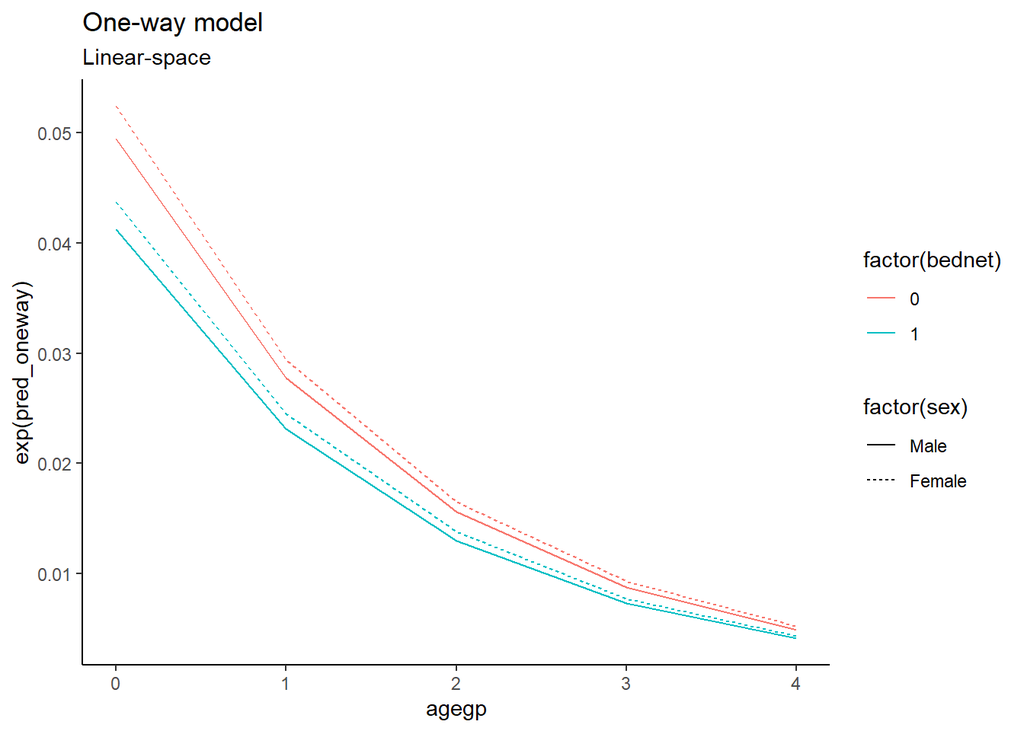

```r
ggplot(pred_dt, aes(x = agegp, y = exp(pred_oneway), lty = factor(sex), col = factor(bednet))) + geom_line() +
  theme_classic() + ggtitle("One-way model", subtitle = "Linear-space")
```

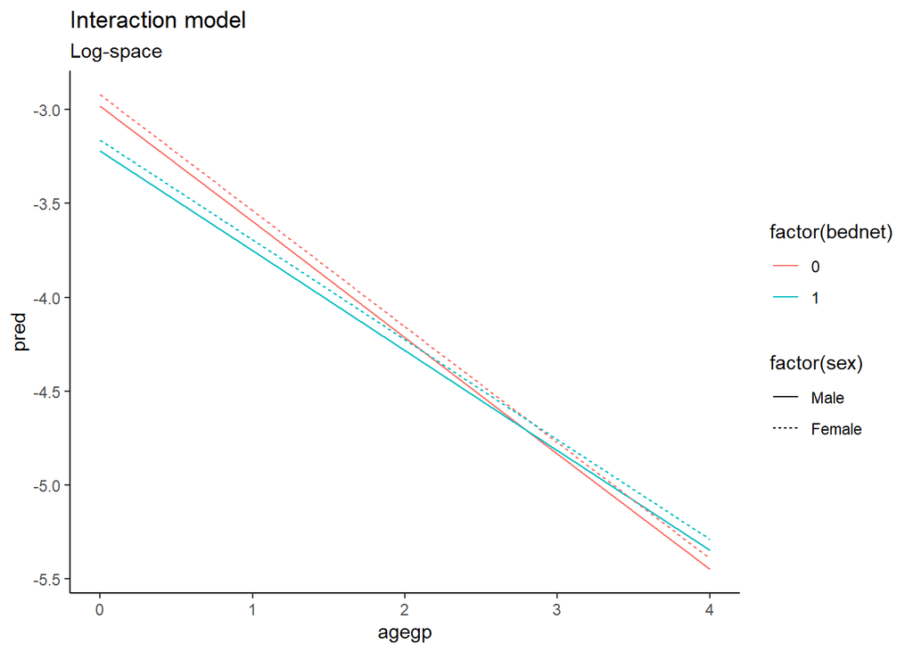

```r
ggplot(pred_dt, aes(x = agegp, y = pred, lty = factor(sex), col = factor(bednet))) + geom_line() +
  theme_classic() + ggtitle("Interaction model", subtitle = "Log-space")
```

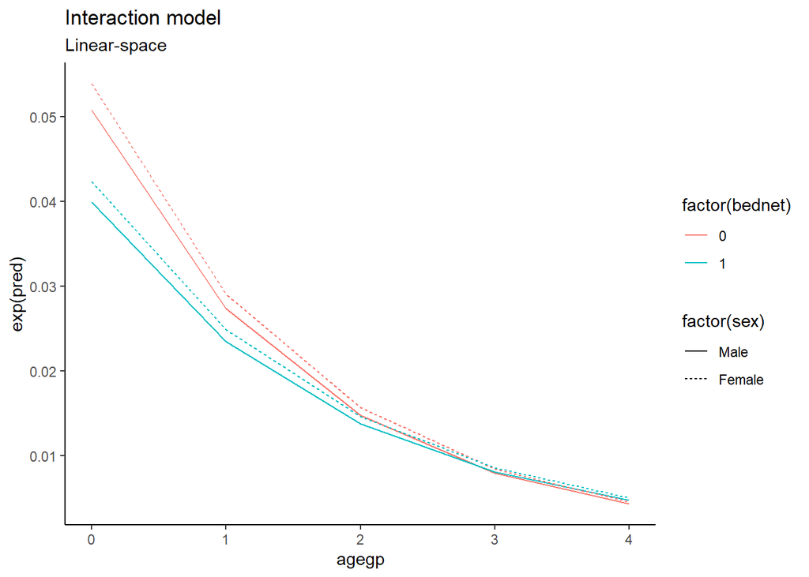

```r
ggplot(pred_dt, aes(x = agegp, y = exp(pred), lty = factor(sex), col = factor(bednet))) + geom_line() +
  theme_classic() + ggtitle("Interaction model", subtitle = "Linear-space")
```

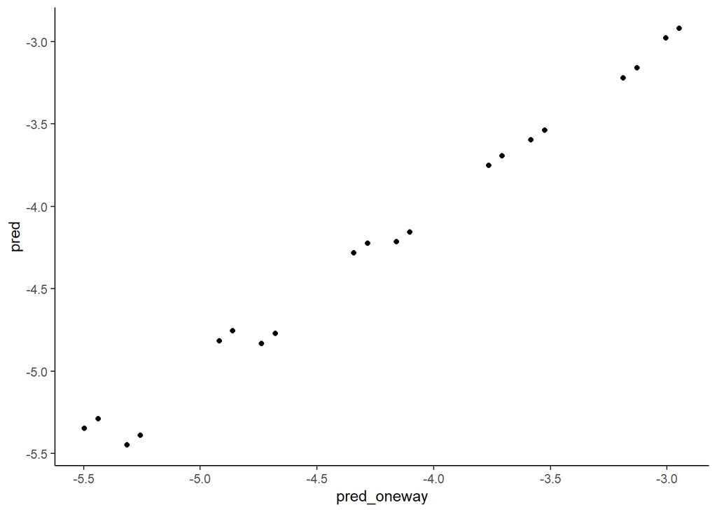

```r
ggplot(pred_dt, aes(x = pred_oneway, y = pred)) + geom_point() +
  theme_classic()
```